# Increased fecundity associates with earlier offspring dispersal and son-bias in cooperative breeding Seychelles warblers

Kiran Gok Lune Lee

2021

## Load packages and data and create dataframes

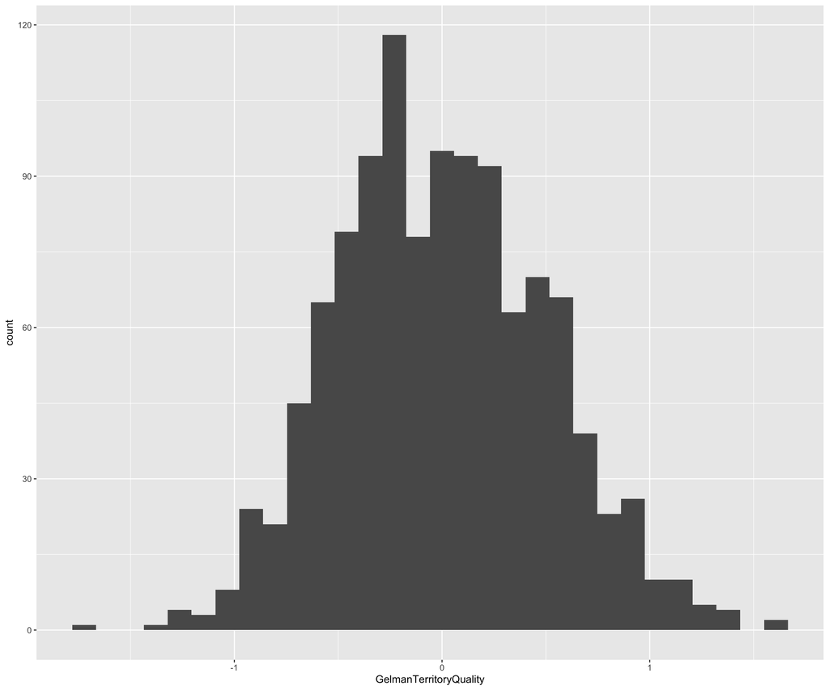

```r
setwd("~/Desktop/Seychelles Warblers/MSc_thesis_Kiran_Lee_2021")
library(ggplot2)
library(dplyr)
library(plyr)
library(tidyverse)
library(ggpubr)
library(lme4)
library(readxl)

# territory quality data
YearlyTQData <- read_excel("YearlyTQ.xlsx")
TQ <- read_excel("TQ.xlsx")
TQ<-rename(TQ, c("PeriodYear"="Year"))
TQ<-rename(TQ, c("TQcorrected"="TerritoryQuality"))
TQ<-subset(TQ,  !is.na(TerritoryQuality))
TQ$logTerritoryQuality<-log(TQ$TerritoryQuality)
TQ$GelmanTerritoryQuality<-(TQ$logTerritoryQuality)-(mean(TQ$logTerritoryQuality))/(2*sd(TQ$logTerritoryQuality))  # transform territory quality

#create dataframe with summary stats for each year on territory quality
TQgroupstata<-ddply(TQ, .(Year),summarise,
        MeanTQ= mean(TerritoryQuality),
        RangeTQ=max(TerritoryQuality)-min(TerritoryQuality),
        sdTQ= sd(TerritoryQuality),
        cvTQ= sdTQ/MeanTQ)

# sex ratio data
FullestSexRatioData <- read_excel("FullestSexRatioData.xlsx")
Data <- subset(FullestSexRatioData, !is.na(Year))
Data <- subset(Data, !is.na(Sex))
Data <- subset(Data, !is.na(TerritoryQuality))
Data <- subset(Data, pParentage>0.5) #choose chicks who's parentage is known with higher than half probability
Data$MumID[Data$MumID == "-998"] <- NA
Data$GelmanTerritoryQuality<-(log(Data$TerritoryQuality)-(mean(log(Data$TerritoryQuality))))/(2*sd(log(Data$TerritoryQuality))) # transform territory quality
ggplot(data=Data, aes(x=GelmanTerritoryQuality))+
  geom_histogram() #histogram to see spread of gelman territory quality. looks good
```

```r
# status of each bird in field season
BirdIDSexYear <- read_excel("BirdIDSexYear.xlsx")

#create dataframe with summary stats per territory and then add this to other dataframes
TerritoryIDGroupStat<-ddply(Data, .(TerritoryID),summarise,
                   MeanTQbetweenyears= mean(TerritoryQuality),
                   RangeTQbetweenyears=max(TerritoryQuality)-min(TerritoryQuality),
                   sdTQbetweenyears= sd(TerritoryQuality),
                   SexRatiobetweenyears= mean(Sex),
                   cvTQbetweenyears= sdTQbetweenyears/MeanTQbetweenyears)
#add cvTQbetweenyears column
Data<-merge(x = Data , y = TerritoryIDGroupStat[ , c("TerritoryID", "cvTQbetweenyears")], by = "TerritoryID", all.x=TRUE)

# subset data so each row is a breedgroup in a field season
TData<-ddply(Data, .(Year, BreedGroupID, TerritoryID, nHelpers, nAB, nABX, nAllAB,nHelpersABX, nAdults,cvTQbetweenyears,nOffspringBreedGroup, FieldPeriodID),summarise, #This subset is important to not pseudoreplicate females offspring sex ratios. It takes the mean sex ratio when clutch size is bigger than 1.
             SexRatio= mean(Sex),
             TerritoryQuality= mean(TerritoryQuality),
             GelmanTerritoryQuality=mean(GelmanTerritoryQuality),
             nFem= length(Sex[Sex=="0"]), # number females per Year and territory ID
             nMale= length(Sex[Sex=="1"]),# number of males per year and territory ID
             nMums=n_distinct(MumID, na.rm = FALSE)

)
#add column of how variable territory qualities are within a year
TData<-merge(x = TData , y = TQgroupstata[ , c("Year", "cvTQ")], by = "Year", all.x=TRUE)
#make breedgroupid a factor
TData$BreedGroupID<- as.factor(TData$BreedGroupID)
#add a column for subordinate non-helpers
TData$NonHelpers<-TData$nAdults - TData$nHelpersABX
#add in the dominant mum and dad id for each breed group
DominantMaleIDSexYear<-subset(BirdIDSexYear, Status=="BrM")
DominantMaleIDSexYear$MaleID<-DominantMaleIDSexYear$BirdID

DominantFemaleIDSexYear<-subset(BirdIDSexYear, Status=="BrF")
DominantFemaleIDSexYear$FemaleID<-DominantFemaleIDSexYear$BirdID

TData<-merge(x = TData, y = DominantMaleIDSexYear[ , c("BreedGroupID", "MaleID")], by = "BreedGroupID", all.x=TRUE)
TData<-merge(x = TData, y = DominantFemaleIDSexYear[ , c("BreedGroupID", "FemaleID")], by = "BreedGroupID", all.x=TRUE)
#add column of how variable a territory's quality is
TData<-merge(x = TData , y = TerritoryIDGroupStat[ , c("TerritoryID", "cvTQbetweenyears")], by = "TerritoryID", all.x=TRUE)
#add column of how variable territory qualities are within a year
TData<-merge(x = TData , y = TQgroupstata[ , c("Year", "cvTQ")], by = "Year", all.x=TRUE)
TData$BreedGroupID<- as.factor(TData$BreedGroupID)


##create dataframe with summary stats for each year on numbers daughters and males and territory quality
DataGroupStat<-ddply(Data, .(Year),summarise,
                   MeanTQ= mean(TerritoryQuality),
                   RangeTQ=max(TerritoryQuality)-min(TerritoryQuality),
                   sdTQ= sd(TerritoryQuality),
                   OffspringSexRatio= mean(Sex), # mean offspring sex ratio had in that year
                   cvTQ= sdTQ/MeanTQ,
                   nDaughters= length(Sex[Sex=="0"]), # number daughters had in that year
                   nSons= length(Sex[Sex=="1"])) # number sons had in that year




# add fieldperiod start and end dates into dataframes
#first create dataframe with summary stats per fieldperiod
FieldPeriodIDGroupStat<-ddply(BirdIDSexYear, .(FieldPeriodID, PeriodEnd, PeriodStart),summarise,
                              nFem= length(Sex[Sex=="0"]),
                              nMale= length(Sex[Sex=="1"]))
FieldPeriodIDGroupStat$PeriodLength<-FieldPeriodIDGroupStat$PeriodEnd-FieldPeriodIDGroupStat$PeriodStart

Data<-merge(x = Data , y = FieldPeriodIDGroupStat [ , c("FieldPeriodID", "PeriodStart")], by = "FieldPeriodID", all.x=TRUE)
Data<-merge(x = Data , y = FieldPeriodIDGroupStat [ , c("FieldPeriodID", "PeriodEnd")], by = "FieldPeriodID", all.x=TRUE)
Data<-merge(x = Data , y = FieldPeriodIDGroupStat [ , c("FieldPeriodID", "PeriodLength")], by = "FieldPeriodID", all.x=TRUE)
TData<-merge(x = TData , y = FieldPeriodIDGroupStat [ , c("FieldPeriodID", "PeriodLength")], by = "FieldPeriodID", all.x=TRUE)

# create sex ratio data including mum's status
PedigreePlusStatus<- read_excel("PedigreePlusStatus.xlsx")
MumStatus <- subset(PedigreePlusStatus, !is.na(Year))
MumStatus <- subset(MumStatus, !is.na(Sex))
MumStatus <- subset(MumStatus, !is.na(TerritoryQuality))
MumStatus <- subset(MumStatus, pParentage>0.5) #choose chicks who's parentage is known with higher than half probability
MumStatus$MumID <- as.character(MumStatus$MumID)
MumStatus$MumID[MumStatus$MumID == "-998"] <- "NA"
MumStatus$MumID<- as.factor(MumStatus$MumID)
MumStatus$TerritoryQuality<-as.numeric(gsub(",", ".", MumStatus$TerritoryQuality))
MumStatus$GelmanTerritoryQuality<-(log(MumStatus$TerritoryQuality)-(mean(log(MumStatus$TerritoryQuality))))/(2*sd(log(MumStatus$TerritoryQuality)))
#add cvTQbetweenyears column
MumStatus<-merge(x = MumStatus , y = TerritoryIDGroupStat[ , c("TerritoryID", "cvTQbetweenyears")], by = "TerritoryID", all.x=TRUE)
Mumstatusgroupstat<-ddply(MumStatus, .(MumID,BreedGroupID,TerritoryID,GelmanTerritoryQuality,FieldPeriodID,nHelpers, nAB, nABX, nAllAB, nHelpersABX, nAdults,Year,cvTQbetweenyears,Status),summarise,
                    OffspringSexRatio= mean(Sex),
                    nFem= length(Sex[Sex=="0"]), # number females per treatment group
                    nMale= length(Sex[Sex=="1"]))

Mumstatusgroupstat$ClutchSize<-Mumstatusgroupstat$nFem+Mumstatusgroupstat$nMale
Mumstatusgroupstat<-merge(x = Mumstatusgroupstat , y = FieldPeriodIDGroupStat [ , c("FieldPeriodID", "PeriodLength")], by = "FieldPeriodID", all.x=TRUE)
# assign dominancy to mums
MumStatus$StatusBrF<-revalue(MumStatus$Status, c(ABX="NonBrF",H="NonBrF",AB="NonBrF",NSA="NonBrF",SEEN1="NonBrF",SEEN2="NonBrF",NS="NonBrF",OFL="NonBrF",SBR="NonBrF",TBRF="NonBrF"))
Mumstatusgroupstat$Dominant<-Mumstatusgroupstat$Status
Mumstatusgroupstat$Dominant[Mumstatusgroupstat$Status!="BrF"] <- 0
Mumstatusgroupstat$Dominant[Mumstatusgroupstat$Status=="BrF"] <- 1
Mumstatusgroupstat$NonHelpers<-Mumstatusgroupstat$nAdults - Mumstatusgroupstat$nHelpersABX
Mumstatusgroupstat$Dominant<-as.factor(Mumstatusgroupstat$Dominant)

#mum group stat. My dataset contains 995 mums and 1034 dads.
Mumgroupstat<-ddply(Data, .(MumID,BreedGroupID,GelmanTerritoryQuality,nHelpers, nAB, nABX, nAllAB,nHelpersABX, nAdults,Year,cvTQbetweenyears,PeriodLength),summarise,
                          OffspringSexRatio= mean(Sex),
                          nFem= length(Sex[Sex=="0"]), # number females per treatment group
                          nMale= length(Sex[Sex=="1"]))

#how many unique breeding events? 396 (when not including -998 who are NA mums)
length(unique(unlist(Mumgroupstat[c("MumID")])))
```

```
## [1] 397
```

```r
Mumgroupstat$ClutchSize<-Mumgroupstat$nFem+Mumgroupstat$nMale

#creating dataframes to study dispersal over subsequent years
Data$YearLater<-Data$Year+1
Data$TwoYearsLater<-Data$Year+2
Data$ThreeYearsLater<-Data$Year+3

#merge status column in BirdIDSexYear if the Year matches YearLater and if BirdID matches ChickID. Here I am basically creating three dataframes where for each bird, there is data on its status after one year (TrialMergeData), two years(TrialMergeData2) or three years (TrialMergeData3)
TrialMergeData = merge(Data, BirdIDSexYear, by.x=c("YearLater", "ChickID"), by.y=c("Year", "BirdID"))
TrialMergeData2 = merge(Data, BirdIDSexYear, by.x=c("TwoYearsLater", "ChickID"), by.y=c("Year","BirdID"))
TrialMergeData3 = merge(Data, BirdIDSexYear, by.x=c("ThreeYearsLater", "ChickID"), by.y=c("Year","BirdID"))

TrialMergeData$MumID<-as.factor(TrialMergeData$MumID)
TrialMergeData2$MumID<-as.factor(TrialMergeData2$MumID)
TrialMergeData3$MumID<-as.factor(TrialMergeData3$MumID)
Mumgroupstat$MumID<-as.factor(Mumgroupstat$MumID)

TrialMergeData$BreedGroupID<-TrialMergeData$BreedGroupID.x
TrialMergeData$BreedGroupID<-as.factor(TrialMergeData$BreedGroupID)
TrialMergeData2$BreedGroupID<-TrialMergeData2$BreedGroupID.x
TrialMergeData2$BreedGroupID<-as.factor(TrialMergeData2$BreedGroupID)
TrialMergeData3$BreedGroupID<-TrialMergeData3$BreedGroupID.x
TrialMergeData3$BreedGroupID<-as.factor(TrialMergeData3$BreedGroupID)
Mumgroupstat$BreedGroupID<-as.factor(Mumgroupstat$BreedGroupID)


TrialMergeData<-left_join(TrialMergeData, Mumgroupstat, by=c('MumID'='MumID', 'Year'='Year', 'BreedGroupID'='BreedGroupID'))
TrialMergeData2<-left_join(TrialMergeData2, Mumgroupstat, by=c('MumID'='MumID', 'Year'='Year', 'BreedGroupID'='BreedGroupID'))
TrialMergeData3<-left_join(TrialMergeData3, Mumgroupstat, by=c('MumID'='MumID', 'Year'='Year', 'BreedGroupID'='BreedGroupID'))

#remove NAs
TrialMergeData$MumID[TrialMergeData$MumID == "NA"] <- NA
TrialMergeData$DadID[TrialMergeData$DadID == -998] <- NA
TrialMergeData<-subset(TrialMergeData, !is.na(MumID))
# assign ranks (1-15) to individuals based on their status
TrialMergeData$RankedStatus<-recode(TrialMergeData$Status, "CH"=1,"BrF" = 1, "BrM" = 1, "H"=2, "OFL" = 3, "FL" = 4, "ABX" = 5, "AB" = 6, "FLOAT" = 7, "SEEN2" = 8, "SEEN1" = 9, "TBRF" = 10, "TBRM" = 10, "U" = 11, "SBR" = 12, "B"=13,"NSA"=14, "NS"=15)

#select chicks whose rank the next year is "highest" if the same chick occurs twice
TrialMergeData<-TrialMergeData %>%
  group_by(ChickID, BreedGroupID, FieldPeriodID.x, Sex.x, YearLater, nOffspringBreedGroup, nAdults.x) %>%
  slice(which.min(RankedStatus))



#remove NAs
TrialMergeData2$MumID[TrialMergeData2$MumID == "NA"] <- NA
TrialMergeData2$DadID[TrialMergeData2$DadID == -998] <- NA
TrialMergeData2<-subset(TrialMergeData2, !is.na(MumID))
# assign ranks (1-15) to individuals based on their status
TrialMergeData2$RankedStatus<-recode(TrialMergeData2$Status, "CH"=1,"BrF" = 1, "BrM" = 1, "H"=2, "OFL" = 3, "FL" = 4, "ABX" = 5, "AB" = 6, "FLOAT" = 7, "SEEN2" = 8, "SEEN1" = 9, "TBRF" = 10, "TBRM" = 10, "U" = 11, "SBR" = 12, "B"=13,"NSA"=14, "NS"=15)

#select chicks whose rank in two years is "highest" if the same chick occurs twice
TrialMergeData2<-TrialMergeData2 %>%
  group_by(ChickID, BreedGroupID, FieldPeriodID.x, Sex.x, YearLater, nOffspringBreedGroup, nAdults.x) %>%
  slice(which.min(RankedStatus))


#remove NAs
TrialMergeData3$MumID[TrialMergeData3$MumID == "NA"] <- NA
TrialMergeData3$DadID[TrialMergeData3$DadID == -998] <- NA
TrialMergeData3<-subset(TrialMergeData3, !is.na(MumID))
# assign ranks (1-15) to individuals based on their status
TrialMergeData3$RankedStatus<-recode(TrialMergeData3$Status, "CH"=1,"BrF" = 1, "BrM" = 1, "H"=2, "OFL" = 3, "FL" = 4, "ABX" = 5, "AB" = 6, "FLOAT" = 7, "SEEN2" = 8, "SEEN1" = 9, "TBRF" = 10, "TBRM" = 10, "U" = 11, "SBR" = 12, "B"=13,"NSA"=14, "NS"=15)

#select chicks whose rank in three years is "highest" if the same chick occurs twice
TrialMergeData3<-TrialMergeData3 %>%
  group_by(ChickID, BreedGroupID, FieldPeriodID.x, Sex.x, YearLater, nOffspringBreedGroup, nAdults.x) %>%
  slice(which.min(RankedStatus))

#add a column for whether they remain on territory or not
TrialMergeData$DispersalStatus<-if_else( TrialMergeData$TerritoryID.x==TrialMergeData$TerritoryID.y, 0, 1)
TrialMergeData2$DispersalStatus<-if_else( TrialMergeData2$TerritoryID.x==TrialMergeData2$TerritoryID.y, 0, 1)
TrialMergeData3$DispersalStatus<-if_else( TrialMergeData3$TerritoryID.x==TrialMergeData3$TerritoryID.y, 0, 1)

#add columns to each dataframe specifying the number of years later for the data of the chick
TrialMergeData$YearsLater<-(TrialMergeData$YearLater/TrialMergeData$YearLater)
TrialMergeData2$YearsLater<-(TrialMergeData2$YearLater/TrialMergeData2$YearLater)+1
TrialMergeData3$YearsLater<-(TrialMergeData3$YearLater/TrialMergeData3$YearLater)+2
TrialMergeData$DispersalStatusOneYear<-TrialMergeData$DispersalStatus
TrialMergeData2$DispersalStatusTwoYears<-TrialMergeData2$DispersalStatus
TrialMergeData3$DispersalStatusThreeYears<-TrialMergeData3$DispersalStatus
TrialMergeData$BreedingStatusOneYear<-TrialMergeData$Status
TrialMergeData2$BreedingStatusTwoYears<-TrialMergeData2$Status
TrialMergeData3$BreedingStatusThreeYears<-TrialMergeData3$Status

# merging relevant data from each TrialMergeData into one dataframe where $YearsLater identifies the number of years since the data is based on
OneYearLater<-data.frame(TrialMergeData$ChickID,TrialMergeData$MumID,TrialMergeData$DadID, TrialMergeData$Sex.x, TrialMergeData$Status,TrialMergeData$DispersalStatus, TrialMergeData$YearsLater, TrialMergeData$nOffspringBreedGroup, TrialMergeData$ClutchSize,TrialMergeData$nAllAB.x,TrialMergeData$nAdults.x,TrialMergeData$BreedGroupID,TrialMergeData$TerritoryID.x,TrialMergeData$GelmanTerritoryQuality.x,TrialMergeData$TerritoryID.y,TrialMergeData$FieldPeriodID.y,TrialMergeData$FieldPeriodID.x,TrialMergeData$YearLater)
TwoYearLater<-data.frame(TrialMergeData2$ChickID,TrialMergeData2$MumID,TrialMergeData2$DadID, TrialMergeData2$Sex.x, TrialMergeData2$Status,TrialMergeData2$DispersalStatus, TrialMergeData2$YearsLater, TrialMergeData2$nOffspringBreedGroup, TrialMergeData2$ClutchSize, TrialMergeData2$nAllAB.x,TrialMergeData2$nAdults.x,TrialMergeData2$BreedGroupID,TrialMergeData2$TerritoryID.x,TrialMergeData2$GelmanTerritoryQuality.x,TrialMergeData2$TerritoryID.y,TrialMergeData2$FieldPeriodID.y,TrialMergeData2$FieldPeriodID.x,TrialMergeData2$YearLater)
ThreeYearLater<-data.frame(TrialMergeData3$ChickID,TrialMergeData3$MumID,TrialMergeData3$DadID, TrialMergeData3$Sex.x, TrialMergeData3$Status,TrialMergeData3$DispersalStatus, TrialMergeData3$YearsLater, TrialMergeData3$nOffspringBreedGroup, TrialMergeData3$ClutchSize,TrialMergeData3$nAllAB.x, TrialMergeData3$nAdults.x,TrialMergeData3$BreedGroupID,TrialMergeData3$TerritoryID.x,TrialMergeData3$GelmanTerritoryQuality.x,TrialMergeData3$TerritoryID.y,TrialMergeData3$FieldPeriodID.y,TrialMergeData3$FieldPeriodID.x,TrialMergeData3$YearLater)
```

```r
#tidy up the spaces and fullstops in the column headings
names(OneYearLater) <- gsub(x = names(OneYearLater),
                            pattern = "\\.",
                            replacement = " ")
names(TwoYearLater) <- gsub(x = names(TwoYearLater),
                            pattern = "\\.",
                            replacement = " ")
names(ThreeYearLater) <- gsub(x = names(ThreeYearLater),
                            pattern = "\\.",
                            replacement = " ")

OneYearLater<-rename(OneYearLater, c("TrialMergeData ChickID"="ChickID",
                                     "TrialMergeData MumID"="MumID",
                                     "TrialMergeData DadID"="DadID",
                                     "TrialMergeData Sex x"="Sex",
                     "TrialMergeData Status"="BreedingStatus",
                     "TrialMergeData DispersalStatus"="DispersalStatus",
                     "TrialMergeData YearsLater"="YearsLater",
                     "TrialMergeData nOffspringBreedGroup"="nOffspringBreedGroup",
                     "TrialMergeData ClutchSize"="ClutchSize",
                     "TrialMergeData nAllAB x"="nAllABx",
                     "TrialMergeData nAdults x"="nAdults",
                     "TrialMergeData BreedGroupID"="BreedGroupID",
                     "TrialMergeData TerritoryID x"="TerritoryIDx",
                     "TrialMergeData GelmanTerritoryQuality x"="GelmanTerritoryQuality",
                     "TrialMergeData TerritoryID y"="TerritoryIDy",
                     "TrialMergeData FieldPeriodID y"="FieldPeriody",
                     "TrialMergeData FieldPeriodID x"="FieldPeriodx",
                     "TrialMergeData YearLater"="YearLater"))
TwoYearLater<-rename(TwoYearLater, c("TrialMergeData2 ChickID"="ChickID",
                                     "TrialMergeData2 MumID"="MumID",
                                     "TrialMergeData2 DadID"="DadID",
                                     "TrialMergeData2 Sex x"="Sex",
                                     "TrialMergeData2 Status"="BreedingStatus",
                                     "TrialMergeData2 DispersalStatus"="DispersalStatus",
                                     "TrialMergeData2 YearsLater"="YearsLater",
                                     "TrialMergeData2 nOffspringBreedGroup"="nOffspringBreedGroup",
                                     "TrialMergeData2 ClutchSize"="ClutchSize",
                                     "TrialMergeData2 BreedGroupID"="BreedGroupID",
                                     "TrialMergeData2 TerritoryID x"="TerritoryIDx",
                                     "TrialMergeData2 GelmanTerritoryQuality x"="GelmanTerritoryQuality",
                                     "TrialMergeData2 TerritoryID y"="TerritoryIDy",
                                     "TrialMergeData2 FieldPeriodID y"="FieldPeriody",
                                     "TrialMergeData2 FieldPeriodID x"="FieldPeriodx",
                                     "TrialMergeData2 nAllAB x"="nAllABx",
                                     "TrialMergeData2 nAdults x"="nAdults",
                                     "TrialMergeData2 YearLater"="YearLater"))
ThreeYearLater<-rename(ThreeYearLater, c("TrialMergeData3 ChickID"="ChickID",
                                         "TrialMergeData3 MumID"="MumID",
                                         "TrialMergeData3 DadID"="DadID",
                                     "TrialMergeData3 Sex x"="Sex",
                                     "TrialMergeData3 Status"="BreedingStatus",
                                     "TrialMergeData3 DispersalStatus"="DispersalStatus",
                                     "TrialMergeData3 YearsLater"="YearsLater",
                                     "TrialMergeData3 nOffspringBreedGroup"="nOffspringBreedGroup",
                                     "TrialMergeData3 ClutchSize"="ClutchSize",
                                     "TrialMergeData3 BreedGroupID"="BreedGroupID",
                                     "TrialMergeData3 TerritoryID x"="TerritoryIDx",
                                     "TrialMergeData3 GelmanTerritoryQuality x"="GelmanTerritoryQuality",
                                     "TrialMergeData3 TerritoryID y"="TerritoryIDy",
                                     "TrialMergeData3 FieldPeriodID y"="FieldPeriody",
                                     "TrialMergeData3 FieldPeriodID x"="FieldPeriodx",
                                     "TrialMergeData3 nAllAB x"="nAllABx",
                                     "TrialMergeData3 nAdults x"="nAdults",
                                     "TrialMergeData3 YearLater"="YearLater"))

AllYearLater<-bind_rows(OneYearLater, TwoYearLater, ThreeYearLater)
#rank status to numbers so that we can exclude those not seen and not known to be alive
AllYearLater$RankedStatus<-AllYearLater$BreedingStatus
AllYearLater$RankedStatus<-recode(AllYearLater$RankedStatus, "CH"=1,"BrF" = 1, "BrM" = 1, "H"=2, "OFL" = 3, "FL" = 4, "ABX" = 5, "AB" = 6, "FLOAT" = 7, "SEEN2" = 8, "SEEN1" = 9, "TBRF" = 10, "TBRM" = 10, "U" = 11, "SBR" = 12, "B"=13,"NSA"=14, "NS"=15)
AllYearLater$BreedGroupSize<-AllYearLater$nAdults+AllYearLater$nOffspringBreedGroup
AllYearLater<-subset(AllYearLater, RankedStatus<14) #remove chicks listed as "NS (not seen) and NSA (not seen known to be alive)
```

## Offspring that could be assigned genetic parentage with at least 50% confidence (mean +/- SE confidence of parentage = 0.98 +/- 0.002, n= 1140) were included

```r
mean(Data$pParentage)
```

```
## [1] 0.9755588
```

```r
sd(Data$pParentage, na.rm = TRUE)/sqrt(length(Data$pParentage[!is.na(Data$pParentage)]))
```

```
## [1] 0.00231845
```

```r
nrow(Data)
```

```
## [1] 1140
```

## three subsequent years as most offspring (this study: 92.1%, n=508) disperse by then

```r
table(AllYearLater$YearsLater, AllYearLater$DispersalStatus)
```

```
##
##       0   1
##   1 394 457
##   2  91 556
##   3  40 468
```

```r
table(Mumgroupstat$ClutchSize)
```

```
##
##   1   2   3   4
## 835 123  17   2
```

```r
mean(Mumgroupstat$ClutchSize)
```

```
## [1] 1.166837
```

```r
sd(Mumgroupstat$ClutchSize, na.rm = TRUE)/sqrt(length(Mumgroupstat$ClutchSize[!is.na(Mumgroupstat$ClutchSize)]))
```

```
## [1] 0.01380802
```

## 13.7% (128/931) of mothers are co-breeding subordinates NB: This statement in my report is incorrect if we run the script (126/932).

```r
table(MumStatus$StatusBrF)
```

```
##
##    BrF NonBrF
##    806    126
```

```r
mean(TData$nOffspringBreedGroup)
```

```
## [1] 1.337196
```

```r
sd(TData$nOffspringBreedGroup, na.rm = TRUE)/sqrt(length(TData$nOffspringBreedGroup[!is.na(TData$nOffspringBreedGroup)]))
```

```
## [1] 0.02321379
```

## Breed groups with more helping subordinates, but not non-helping subordinates produce more offspring (figure 1), with no impact of territory quality or field period length in which sampling took place (table 1)

```r
# Territories with more helpers have larger clutches
# visually
table(TData$nHelpers)
```

```
##
##   0   1   2   3
## 656 180  25   2
```

[figure not shown]

```r
ggplot(data = subset(TData), aes(x = factor(nHelpers), y = nOffspringBreedGroup)) +
    geom_violin() + stat_summary(fun.data = mean_sdl, mult = 1,
    geom = "pointrange", color = "red") + geom_jitter(alpha = 0.25,
    width = 0.2, height = 0.1) + ylim(1, 7) + labs(x = "number of helping subordinates",
    y = "number of offspring born") + theme(axis.title.x = element_text(size = rel(2)),
    axis.title.y = element_text(size = rel(2)), axis.text = element_text(size = rel(1.5))) +
    annotate("text", size = 5, y = 0.5, x = 1, label = "n=2") +
    annotate("text", size = 5, y = 0.5, x = 2, label = "n=25") +
    annotate("text", size = 5, y = 0.5, x = 3, label = "n=180") +
    annotate("text", size = 5, y = 0.5, x = 4, label = "n=656") +
    ylim(0.5, 7)
```

```r
mm <- glmer(nOffspringBreedGroup ~ GelmanTerritoryQuality + nHelpers +
    NonHelpers + PeriodLength + (1 | TerritoryID) + (1 | FieldPeriodID) +
    (1 | MaleID) + (1 | FemaleID), data = TData, family = poisson)
```

```
## boundary (singular) fit: see help('isSingular')
```

```r
summary(mm)
```

```
## Generalized linear mixed model fit by maximum likelihood (Laplace
##   Approximation) [glmerMod]
##  Family: poisson  ( log )
## Formula:
## nOffspringBreedGroup ~ GelmanTerritoryQuality + nHelpers + NonHelpers +
##     PeriodLength + (1 | TerritoryID) + (1 | FieldPeriodID) +
##     (1 | MaleID) + (1 | FemaleID)
##    Data: TData
##
##      AIC      BIC   logLik deviance df.resid
##   2086.0   2128.7  -1034.0   2068.0      839
##
## Scaled residuals:
##     Min      1Q  Median      3Q     Max
## -0.6244 -0.2863 -0.2203  0.1089  4.8177
##
## Random effects:
##  Groups        Name        Variance Std.Dev.
##  MaleID        (Intercept) 0        0
##  FemaleID      (Intercept) 0        0
##  TerritoryID   (Intercept) 0        0
##  FieldPeriodID (Intercept) 0        0
## Number of obs: 848, groups:
## MaleID, 333; FemaleID, 320; TerritoryID, 114; FieldPeriodID, 26
##
## Fixed effects:
##                          Estimate Std. Error z value Pr(>|z|)
## (Intercept)             0.2405179  0.1137032   2.115  0.03440 *
## GelmanTerritoryQuality  0.0873263  0.0622716   1.402  0.16081
## nHelpers                0.1640740  0.0532151   3.083  0.00205 **
## NonHelpers              0.0299286  0.0327653   0.913  0.36102
## PeriodLength           -0.0002375  0.0013432  -0.177  0.85963
## ---
## Signif. codes:  0 '***' 0.001 '**' 0.01 '*' 0.05 '.' 0.1 ' ' 1
##
## Correlation of Fixed Effects:
##             (Intr) GlmnTQ nHlprs NnHlpr
## GlmnTrrtryQ -0.070
## nHelpers    -0.014 -0.022
## NonHelpers  -0.200 -0.142 -0.127
## PeriodLngth -0.930  0.111 -0.116 -0.011
## optimizer (Nelder_Mead) convergence code: 0 (OK)
## boundary (singular) fit: see help('isSingular')
```

```r
drop1(mm, test = "Chisq")
```

```
## boundary (singular) fit: see help('isSingular')
```

```
## boundary (singular) fit: see help('isSingular')
## boundary (singular) fit: see help('isSingular')
## boundary (singular) fit: see help('isSingular')
```

```
## Single term deletions
##
## Model:
## nOffspringBreedGroup ~ GelmanTerritoryQuality + nHelpers + NonHelpers +
##     PeriodLength + (1 | TerritoryID) + (1 | FieldPeriodID) +
##     (1 | MaleID) + (1 | FemaleID)
##                        npar    AIC    LRT  Pr(Chi)
## <none>                      2086.0
## GelmanTerritoryQuality    1 2086.0 1.9655 0.160925
## nHelpers                  1 2093.1 9.0494 0.002628 **
## NonHelpers                1 2084.9 0.8244 0.363887
## PeriodLength              1 2084.1 0.0313 0.859683
## ---
## Signif. codes:  0 '***' 0.001 '**' 0.01 '*' 0.05 '.' 0.1 ' ' 1
```

## Breed groups in better quality territories sustain more adult individuals (estimate= 0.179, SE= 0.080, p= 0.025, figure 2)

```r
mmm <- glmer(nAdults ~ GelmanTerritoryQuality + (1 | FieldPeriodID) +
    (1 | TerritoryID) + (1 | MaleID) + (1 | FemaleID), data = TData,
    family = poisson)
summary(mmm)
```

```
## Generalized linear mixed model fit by maximum likelihood (Laplace
##   Approximation) [glmerMod]
##  Family: poisson  ( log )
## Formula: nAdults ~ GelmanTerritoryQuality + (1 | FieldPeriodID) + (1 |
##     TerritoryID) + (1 | MaleID) + (1 | FemaleID)
##    Data: TData
##
##      AIC      BIC   logLik deviance df.resid
##   2469.5   2497.9  -1228.7   2457.5      842
##
## Scaled residuals:
##      Min       1Q   Median       3Q      Max
## -1.47526 -0.82444 -0.08846  0.50155  2.85150
##
## Random effects:
##  Groups        Name        Variance Std.Dev.
##  MaleID        (Intercept) 0.003399 0.0583
##  FemaleID      (Intercept) 0.131519 0.3627
##  TerritoryID   (Intercept) 0.039619 0.1990
##  FieldPeriodID (Intercept) 0.018116 0.1346
## Number of obs: 848, groups:
## MaleID, 333; FemaleID, 320; TerritoryID, 114; FieldPeriodID, 26
##
## Fixed effects:
##                        Estimate Std. Error z value Pr(>|z|)
## (Intercept)             0.15131    0.05595   2.704  0.00684 **
## GelmanTerritoryQuality  0.17946    0.08031   2.235  0.02545 *
## ---
## Signif. codes:  0 '***' 0.001 '**' 0.01 '*' 0.05 '.' 0.1 ' ' 1
##
## Correlation of Fixed Effects:
##             (Intr)
## GlmnTrrtryQ 0.009
```

```r
drop1(mmm, test = "Chisq")
```

```
## boundary (singular) fit: see help('isSingular')
```

```
## Single term deletions
##
## Model:
## nAdults ~ GelmanTerritoryQuality + (1 | FieldPeriodID) + (1 |
##     TerritoryID) + (1 | MaleID) + (1 | FemaleID)
##                        npar    AIC    LRT Pr(Chi)
## <none>                      2469.5
## GelmanTerritoryQuality    1 2472.3 4.7703 0.02895 *
## ---
## Signif. codes:  0 '***' 0.001 '**' 0.01 '*' 0.05 '.' 0.1 ' ' 1
```

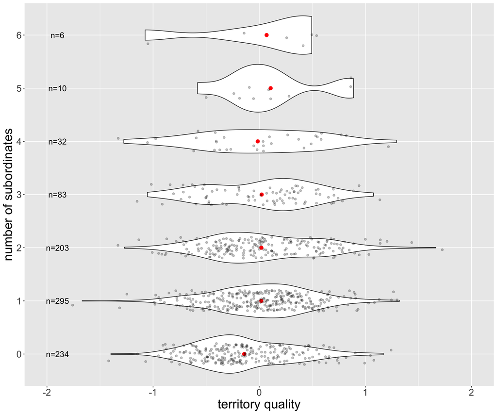

```r
ggplot(data = TData, aes(x = factor(nAdults), y = GelmanTerritoryQuality)) +
    geom_violin() + coord_flip() + stat_summary(fun.y = mean,
    mult = 1, geom = "pointrange", color = "red") + geom_jitter(alpha = 0.25,
    width = 0.2, height = 0.1) + labs(x = "number of subordinates",
    y = "territory quality") + theme(axis.title.x = element_text(size = rel(2)),
    axis.title.y = element_text(size = rel(2)), axis.text = element_text(size = rel(1.5))) +
    annotate("text", size = 5, y = -1.9, x = 7, label = "n=6") +
    annotate("text", size = 5, y = -1.9, x = 6, label = "n=10") +
    annotate("text", size = 5, y = -1.9, x = 5, label = "n=32") +
    annotate("text", size = 5, y = -1.9, x = 4, label = "n=83") +
    annotate("text", size = 5, y = -1.9, x = 3, label = "n=203") +
    annotate("text", size = 5, y = -1.9, x = 2, label = "n=295") +
    annotate("text", size = 5, y = -1.9, x = 1, label = "n=234") +
    ylim(-2.01, 2.01)
```

```r
mmm <- glmer(ClutchSize ~ GelmanTerritoryQuality + nHelpers +
    Dominant + NonHelpers + PeriodLength + (1 | TerritoryID) +
    (1 | MumID), data = subset(Mumstatusgroupstat), family = poisson)
```

```
## boundary (singular) fit: see help('isSingular')
```

```r
summary(mmm)
```

```
## Generalized linear mixed model fit by maximum likelihood (Laplace
##   Approximation) [glmerMod]
##  Family: poisson  ( log )
## Formula:
## ClutchSize ~ GelmanTerritoryQuality + nHelpers + Dominant + NonHelpers +
##     PeriodLength + (1 | TerritoryID) + (1 | MumID)
##    Data: subset(Mumstatusgroupstat)
##
##      AIC      BIC   logLik deviance df.resid
##   1784.4   1821.8   -884.2   1768.4      784
##
## Scaled residuals:
##     Min      1Q  Median      3Q     Max
## -0.2992 -0.1709 -0.1462 -0.1230  2.4009
##
## Random effects:
##  Groups      Name        Variance Std.Dev.
##  MumID       (Intercept) 0        0
##  TerritoryID (Intercept) 0        0
## Number of obs: 792, groups:  MumID, 331; TerritoryID, 115
##
## Fixed effects:
##                         Estimate Std. Error z value Pr(>|z|)
## (Intercept)            0.0969561  0.1533686   0.632    0.527
## GelmanTerritoryQuality 0.0391033  0.0681551   0.574    0.566
## nHelpers               0.0609382  0.0618746   0.985    0.325
## Dominant1              0.0318834  0.1024194   0.311    0.756
## NonHelpers             0.0027912  0.0356963   0.078    0.938
## PeriodLength           0.0002029  0.0015071   0.135    0.893
##
## Correlation of Fixed Effects:
##             (Intr) GlmnTQ nHlprs Dmnnt1 NnHlpr
## GlmnTrrtryQ -0.050
## nHelpers    -0.197 -0.033
## Dominant1   -0.562 -0.017  0.303
## NonHelpers  -0.242 -0.145 -0.081  0.144
## PeriodLngth -0.705  0.116 -0.123 -0.107 -0.028
## optimizer (Nelder_Mead) convergence code: 0 (OK)
## boundary (singular) fit: see help('isSingular')
```

```r
table(AllYearLater$YearsLater, AllYearLater$DispersalStatus)
```

```
##
##       0   1
##   1 394 457
##   2  91 556
##   3  40 468
```

This script no longer produces the trend line in my thesis. I have tried troubleshooting but without success.

```r
m2 <- glmer(DispersalStatus ~ Sex + GelmanTerritoryQuality +
    nOffspringBreedGroup * YearsLater + nAdults + (1 | BreedGroupID) +
    (1 | FieldPeriodx) + (1 | TerritoryIDx) + (1 | MumID) + (1 |
    DadID), data = AllYearLater, family = binomial)
summary(m2)
```

```
## Generalized linear mixed model fit by maximum likelihood (Laplace
##   Approximation) [glmerMod]
##  Family: binomial  ( logit )
## Formula:
## DispersalStatus ~ Sex + GelmanTerritoryQuality + nOffspringBreedGroup *
##     YearsLater + nAdults + (1 | BreedGroupID) + (1 | FieldPeriodx) +
##     (1 | TerritoryIDx) + (1 | MumID) + (1 | DadID)
##    Data: AllYearLater
##
##      AIC      BIC   logLik deviance df.resid
##   1806.3   1873.4   -891.1   1782.3     1974
##
## Scaled residuals:
##     Min      1Q  Median      3Q     Max
## -6.1557 -0.2150  0.1422  0.4026  6.2420
##
## Random effects:
##  Groups       Name        Variance Std.Dev.
##  BreedGroupID (Intercept) 2.716379 1.64814
##  MumID        (Intercept) 2.060371 1.43540
##  DadID        (Intercept) 0.499726 0.70691
##  TerritoryIDx (Intercept) 0.001011 0.03179
##  FieldPeriodx (Intercept) 0.511887 0.71546
## Number of obs: 1986, groups:
## BreedGroupID, 694; MumID, 353; DadID, 347; TerritoryIDx, 110; FieldPeriodx, 26
##
## Fixed effects:
##                                 Estimate Std. Error z value Pr(>|z|)
## (Intercept)                      -2.8395     0.5162  -5.500 3.79e-08 ***
## Sex                               0.1812     0.2115   0.857  0.39163
## GelmanTerritoryQuality            0.3203     0.3304   0.969  0.33241
## nOffspringBreedGroup              0.5707     0.2385   2.392  0.01674 *
## YearsLater                        2.7598     0.3029   9.110  < 2e-16 ***
## nAdults                           0.1378     0.1046   1.318  0.18751
## nOffspringBreedGroup:YearsLater  -0.3473     0.1228  -2.828  0.00468 **
## ---
## Signif. codes:  0 '***' 0.001 '**' 0.01 '*' 0.05 '.' 0.1 ' ' 1
##
## Correlation of Fixed Effects:
##             (Intr) Sex    GlmnTQ nOffBG YrsLtr nAdlts
## Sex         -0.196
## GlmnTrrtryQ  0.064 -0.015
## nOffsprngBG -0.741 -0.047 -0.055
## YearsLater  -0.744  0.032  0.015  0.619
## nAdults     -0.245  0.009 -0.042 -0.075  0.077
## nOffspBG:YL  0.663 -0.002  0.004 -0.773 -0.824 -0.035
## optimizer (Nelder_Mead) convergence code: 0 (OK)
## Model failed to converge with max|grad| = 0.513228 (tol = 0.002, component 1)
```

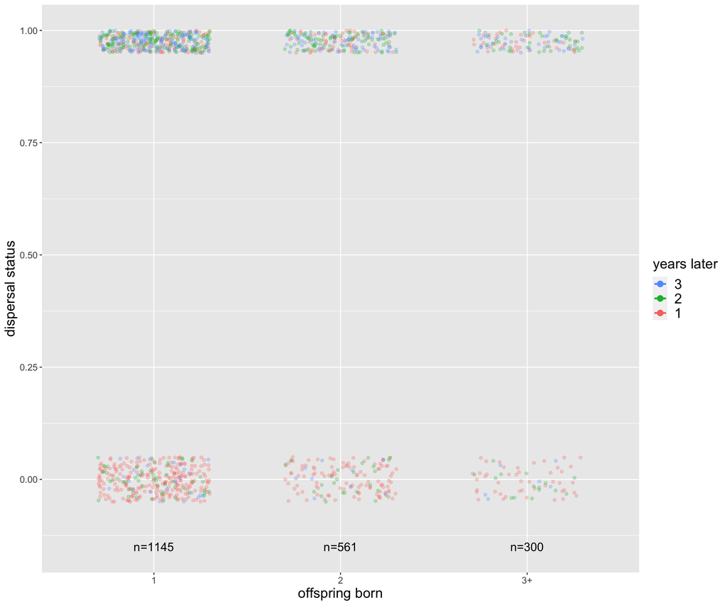

```r
AllYearLater$nOffspringBreedGroupMerged <- AllYearLater$nOffspringBreedGroup
AllYearLater$nOffspringBreedGroupMerged[AllYearLater$nOffspringBreedGroupMerged >
    2] <- "3+"

ggplot(data = subset(AllYearLater, YearsLater != 0), aes(x = factor(nOffspringBreedGroupMerged),
    y = (DispersalStatus), color = factor(YearsLater))) + stat_summary(fun.data = mean_sdl,
    mult = 1, geom = "point", line = "dotted", size = 3) + stat_summary(aes(group = 1,
    color = factor(YearsLater)), fun.data = mean_sdl, mult = 1,
    geom = "line") + geom_jitter(alpha = 0.25, width = 0.3, height = 0.05) +
    geom_smooth(method = "lm", se = F) + ylim(-0.15, 1) + labs(x = "offspring born",
    y = "dispersal status", color = "years later") + theme(legend.direction = "vertical") +
    guides(color = guide_legend(reverse = TRUE)) + theme(axis.title.x = element_text(size = rel(1.5)),
    axis.title.y = element_text(size = rel(1.5)), axis.text = element_text(size = rel(1)),
    legend.text = element_text(size = rel(1.5)), legend.title = element_text(size = rel(1.5))) +
    theme(legend.background = element_blank()) + annotate("text",
    size = 5, x = 1, y = -0.15, label = "n=1145") + annotate("text",
    size = 5, x = 2, y = -0.15, label = "n=561") + annotate("text",
    size = 5, x = 3, y = -0.15, label = "n=300")
```

## Sons become dominants more than daughters in each year (estimate= 0.301, SE= 0.101 p= 0.003)

```r
AllYearLater$Dominant <- AllYearLater$RankedStatus
AllYearLater$Dominant[AllYearLater$RankedStatus == 1] <- 1
AllYearLater$Dominant[AllYearLater$RankedStatus > 1] <- 0
m <- glmer(Dominant ~ Sex + GelmanTerritoryQuality + nOffspringBreedGroup +
    nAllABx + (1 | TerritoryIDx) + (1 | FieldPeriodx) + (1 |
    MumID) + (1 | DadID), data = AllYearLater, family = binomial)
```

```
## boundary (singular) fit: see help('isSingular')
```

```r
summary(m)
```

```
## Generalized linear mixed model fit by maximum likelihood (Laplace
##   Approximation) [glmerMod]
##  Family: binomial  ( logit )
## Formula: Dominant ~ Sex + GelmanTerritoryQuality + nOffspringBreedGroup +
##     nAllABx + (1 | TerritoryIDx) + (1 | FieldPeriodx) + (1 |
##     MumID) + (1 | DadID)
##    Data: AllYearLater
##
##      AIC      BIC   logLik deviance df.resid
##   2644.4   2694.7  -1313.2   2626.4     1977
##
## Scaled residuals:
##     Min      1Q  Median      3Q     Max
## -2.1968 -1.0147  0.5995  0.8166  1.4117
##
## Random effects:
##  Groups       Name        Variance  Std.Dev.
##  MumID        (Intercept) 7.730e-02 2.780e-01
##  DadID        (Intercept) 1.083e-01 3.291e-01
##  TerritoryIDx (Intercept) 2.659e-09 5.156e-05
##  FieldPeriodx (Intercept) 2.767e-01 5.260e-01
## Number of obs: 1986, groups:
## MumID, 353; DadID, 347; TerritoryIDx, 110; FieldPeriodx, 26
##
## Fixed effects:
##                        Estimate Std. Error z value Pr(>|z|)
## (Intercept)             0.44153    0.16205   2.725  0.00644 **
## Sex                     0.30063    0.10141   2.965  0.00303 **
## GelmanTerritoryQuality  0.25213    0.15001   1.681  0.09281 .
## nOffspringBreedGroup   -0.04169    0.05851  -0.712  0.47619
## nAllABx                -0.06052    0.06896  -0.878  0.38017
## ---
## Signif. codes:  0 '***' 0.001 '**' 0.01 '*' 0.05 '.' 0.1 ' ' 1
##
## Correlation of Fixed Effects:
##             (Intr) Sex    GlmnTQ nOffBG
## Sex         -0.276
## GlmnTrrtryQ  0.087 -0.005
## nOffsprngBG -0.496 -0.069 -0.062
## nAllABx     -0.198 -0.018 -0.003 -0.139
## optimizer (Nelder_Mead) convergence code: 0 (OK)
## boundary (singular) fit: see help('isSingular')
```

## 89.6% (241/269) of sons becoming dominant and 82.8% (198/239) of daughters becoming dominant three years later

```r
table(AllYearLater$YearsLater, AllYearLater$Dominant, AllYearLater$Sex)
```

```
## , ,  = 0
##
##
##       0   1
##   1 293 115
##   2  87 214
##   3  41 198
##
## , ,  = 1
##
##
##       0   1
##   1 303 140
##   2  74 272
##   3  28 241
```

```r
241/(241 + 28)  # sons
```

```
## [1] 0.8959108
```

```r
198/(198 + 41)  # daughters
```

```
## [1] 0.8284519
```

## There is no impact of natal territory quality (estimate= 0. 252, SE= 0.150, p= 0.093), the number of offspring co-born in the natal territory (estimate= -0.042, SE= 0.059, p= 0.476) or the number of adult subordinates in the natal territory (estimate= -0.061, SE= 0.069, p= 0.380) on whether offspring established dominancy in subsequent years.

```r
summary(m)
```

```
## Generalized linear mixed model fit by maximum likelihood (Laplace
##   Approximation) [glmerMod]
##  Family: binomial  ( logit )
## Formula: Dominant ~ Sex + GelmanTerritoryQuality + nOffspringBreedGroup +
##     nAllABx + (1 | TerritoryIDx) + (1 | FieldPeriodx) + (1 |
##     MumID) + (1 | DadID)
##    Data: AllYearLater
##
##      AIC      BIC   logLik deviance df.resid
##   2644.4   2694.7  -1313.2   2626.4     1977
##
## Scaled residuals:
##     Min      1Q  Median      3Q     Max
## -2.1968 -1.0147  0.5995  0.8166  1.4117
##
## Random effects:
##  Groups       Name        Variance  Std.Dev.
##  MumID        (Intercept) 7.730e-02 2.780e-01
##  DadID        (Intercept) 1.083e-01 3.291e-01
##  TerritoryIDx (Intercept) 2.659e-09 5.156e-05
##  FieldPeriodx (Intercept) 2.767e-01 5.260e-01
## Number of obs: 1986, groups:
## MumID, 353; DadID, 347; TerritoryIDx, 110; FieldPeriodx, 26
##
## Fixed effects:
##                        Estimate Std. Error z value Pr(>|z|)
## (Intercept)             0.44153    0.16205   2.725  0.00644 **
## Sex                     0.30063    0.10141   2.965  0.00303 **
## GelmanTerritoryQuality  0.25213    0.15001   1.681  0.09281 .
## nOffspringBreedGroup   -0.04169    0.05851  -0.712  0.47619
## nAllABx                -0.06052    0.06896  -0.878  0.38017
## ---
## Signif. codes:  0 '***' 0.001 '**' 0.01 '*' 0.05 '.' 0.1 ' ' 1
##
## Correlation of Fixed Effects:
##             (Intr) Sex    GlmnTQ nOffBG
## Sex         -0.276
## GlmnTrrtryQ  0.087 -0.005
## nOffsprngBG -0.496 -0.069 -0.062
## nAllABx     -0.198 -0.018 -0.003 -0.139
## optimizer (Nelder_Mead) convergence code: 0 (OK)
## boundary (singular) fit: see help('isSingular')
```

## Dominant mothers male-bias offspring sex ratios when increasing the number of offspring produced, despite even mean offspring sex-ratios (0.48) (table 3, Fig. 3a)…There is no influence of territory quality or the number of adult subordinates in the territory on offspring sex-ratios

```r
m <- glmer(cbind(nMale, nFem) ~ ClutchSize + Dominant + GelmanTerritoryQuality +
    nHelpers + cvTQbetweenyears + (1 | MumID) + (1 | FieldPeriodID) +
    (1 | TerritoryID), data = subset(Mumstatusgroupstat, !is.na(cvTQbetweenyears)),
    family = binomial)
```

```
## boundary (singular) fit: see help('isSingular')
```

```r
summary(m)
```

```
## Generalized linear mixed model fit by maximum likelihood (Laplace
##   Approximation) [glmerMod]
##  Family: binomial  ( logit )
## Formula: cbind(nMale, nFem) ~ ClutchSize + Dominant + GelmanTerritoryQuality +
##     nHelpers + cvTQbetweenyears + (1 | MumID) + (1 | FieldPeriodID) +
##     (1 | TerritoryID)
##    Data: subset(Mumstatusgroupstat, !is.na(cvTQbetweenyears))
##
##      AIC      BIC   logLik deviance df.resid
##   1181.6   1223.6   -581.8   1163.6      775
##
## Scaled residuals:
##     Min      1Q  Median      3Q     Max
## -2.4026 -0.9377 -0.1406  1.0413  1.4666
##
## Random effects:
##  Groups        Name        Variance  Std.Dev.
##  MumID         (Intercept) 0.000e+00 0.000e+00
##  TerritoryID   (Intercept) 2.748e-02 1.658e-01
##  FieldPeriodID (Intercept) 9.359e-10 3.059e-05
## Number of obs: 784, groups:  MumID, 324; TerritoryID, 107; FieldPeriodID, 26
##
## Fixed effects:
##                        Estimate Std. Error z value Pr(>|z|)
## (Intercept)             0.32953    0.31476   1.047   0.2951
## ClutchSize              0.28612    0.11662   2.453   0.0142 *
## Dominant1              -0.52219    0.21225  -2.460   0.0139 *
## GelmanTerritoryQuality  0.13164    0.13622   0.966   0.3338
## nHelpers                0.01018    0.12768   0.080   0.9364
## cvTQbetweenyears       -0.27263    0.22248  -1.225   0.2204
## ---
## Signif. codes:  0 '***' 0.001 '**' 0.01 '*' 0.05 '.' 0.1 ' ' 1
##
## Correlation of Fixed Effects:
##             (Intr) CltchS Dmnnt1 GlmnTQ nHlprs
## ClutchSize  -0.415
## Dominant1   -0.618 -0.022
## GlmnTrrtryQ  0.027 -0.075 -0.024
## nHelpers    -0.275 -0.120  0.314 -0.010
## cvTQbtwnyrs -0.572 -0.082  0.001  0.041  0.028
## optimizer (Nelder_Mead) convergence code: 0 (OK)
## boundary (singular) fit: see help('isSingular')
```

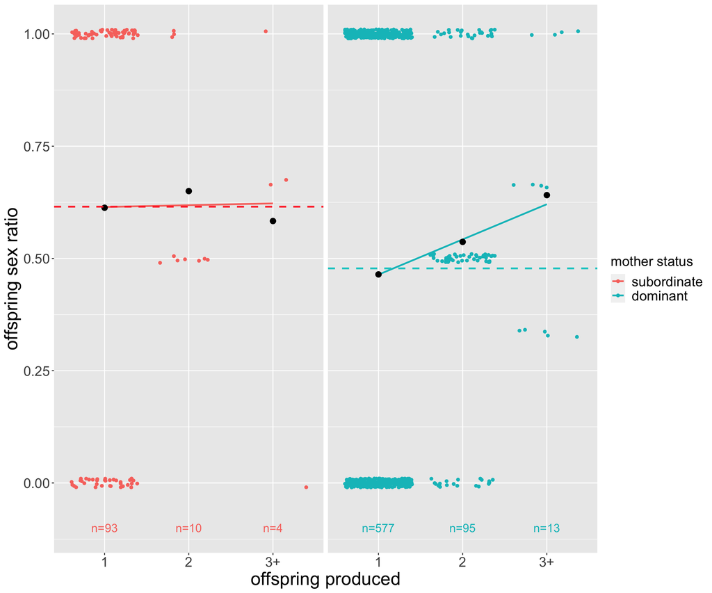

```r
Mumstatusgroupstat$ClutchSizeMerged <- Mumstatusgroupstat$ClutchSize
Mumstatusgroupstat$ClutchSizeMerged[Mumstatusgroupstat$ClutchSizeMerged >
    2] <- "3+"
lables <- c(`1` = "Dominant", `0` = "Subordinate")
dat_text <- data.frame(Dominant = c("1", "1", "1", "0", "0",
    "0"), lables = c("n=577", "n=95", "n=13", "n=93", "n=10",
    "n=4"), x = c(1, 2, 3, 1, 2, 3), y = c(-0.1, -0.1, -0.1,
    -0.1, -0.1, -0.1))
ggplot(subset(Mumstatusgroupstat), aes(x = ClutchSizeMerged,
    y = OffspringSexRatio, color = Dominant, group = Dominant)) +
    geom_jitter(width = 0.4, height = 0.01) + geom_smooth(method = lm,
    se = F) + stat_summary(geom = "point", fun.y = "mean", col = "black",
    size = 3, shape = 21, fill = "black") + facet_grid(col = vars(Dominant),
    labeller = labeller(Dominant = lables)) + geom_hline(data = filter(Mumstatusgroupstat,
    Status == "BrF"), aes(yintercept = mean(Mumstatusgroupstat$OffspringSexRatio[Mumstatusgroupstat$Status ==
    "BrF"])), linetype = "dashed", size = 1, width = 0.5, colour = "#00CCCC") +
    geom_hline(data = filter(Mumstatusgroupstat, Status != "BrF"),
        aes(yintercept = mean(Mumstatusgroupstat$OffspringSexRatio[Mumstatusgroupstat$Status !=
            "BrF"])), linetype = "dashed", size = 1, width = 0.5,
        colour = "#FF3333") + labs(x = "offspring produced",
    y = "offspring sex ratio") + theme(axis.title.x = element_text(size = rel(2)),
    axis.title.y = element_text(size = rel(2)), axis.text = element_text(size = rel(1.5)),
    legend.title = element_text(size = rel(1.5)), legend.text = element_text(size = rel(1.5)),
    strip.background = element_blank(), strip.text.x = element_blank()) +
    scale_color_discrete(name = "mother status", breaks = c("0",
        "1"), labels = c("subordinate", "dominant")) + geom_text(size = 5,
    data = dat_text, aes(x = x, y = y, label = lables), show.legend = FALSE)
```

## maintaining a male-biased mean offspring sex-ratio of 0.62 (78/126, two-tailed binomial test= 0.009)

```r
binom.test(x = 78, n = 126, p = 1/2, alternative = "two.sided")
```

```
##
##  Exact binomial test
##
## data:  78 and 126
## number of successes = 78, number of trials = 126, p-value = 0.009503
## alternative hypothesis: true probability of success is not equal to 0.5
## 95 percent confidence interval:
##  0.5282941 0.7040691
## sample estimates:
## probability of success
##              0.6190476
```